# Gazebos of Indiana

- Show All Code
- Hide All Code
- View Source

2025 Report on distribution, morphology, and habitat associations

Author

Affiliations

Matthew L. Sisk

Civic-Geospatial Analysis and Learning Lab, LFIDS

Society for the Conservation and Understanding of Gazebos

Published

August 17, 2026

**See code**

```r
rm(list = ls())
library(tidyverse)
library(sf)
library(scales)
library(leaflet)

gdb <- "c:/Users/msisk1/Downloads/RealProperty_2025.gdb/"

cache_dir <- "cache"
if (!dir.exists(cache_dir)) dir.create(cache_dir)

read_or_build <- function(path, build_fn) {
  if (file.exists(path)) {
    readRDS(path)
  } else {
    obj <- build_fn()
    saveRDS(obj, path)
    obj
  }
}

theme_academic <- function(base_size = 11) {
  theme_bw(base_size = base_size) +
    theme(
      panel.grid.minor = element_blank(),
      plot.title    = element_text(face = "bold", size = base_size),
      plot.caption  = element_text(hjust = 0, size = base_size - 2, color = "grey30"),
      strip.background = element_rect(fill = "grey90", color = NA)
    )
}

# ggplot's labs(caption=) doesn't wrap text on its own; table captions
# already wrap fine as normal HTML text, only plot captions need this.
wrap_cap <- function(x, width = 150) str_wrap(x, width = width)

county_lookup <- tibble(
  COUNTY_NUMBER = sprintf("%02d", 1:92),
  COUNTY_NAME = c(
    "Adams", "Allen", "Bartholomew", "Benton", "Blackford", "Boone", "Brown",
    "Carroll", "Cass", "Clark", "Clay", "Clinton", "Crawford", "Daviess",
    "Dearborn", "Decatur", "DeKalb", "Delaware", "Dubois", "Elkhart",
    "Fayette", "Floyd", "Fountain", "Franklin", "Fulton", "Gibson", "Grant",
    "Greene", "Hamilton", "Hancock", "Harrison", "Hendricks", "Henry",
    "Howard", "Huntington", "Jackson", "Jasper", "Jay", "Jefferson",
    "Jennings", "Johnson", "Knox", "Kosciusko", "LaGrange", "Lake",
    "LaPorte", "Lawrence", "Madison", "Marion", "Marshall", "Martin",
    "Miami", "Monroe", "Montgomery", "Morgan", "Newton", "Noble", "Ohio",
    "Orange", "Owen", "Parke", "Perry", "Pike", "Porter", "Posey",
    "Pulaski", "Putnam", "Randolph", "Ripley", "Rush", "St. Joseph",
    "Scott", "Shelby", "Spencer", "Starke", "Steuben", "Sullivan",
    "Switzerland", "Tippecanoe", "Tipton", "Union", "Vanderburgh",
    "Vermillion", "Vigo", "Wabash", "Warren", "Warrick", "Washington",
    "Wayne", "Wells", "White", "Whitley"
  )
)
```

**NoteAbstract**

In this annual report, we characterize the distribution, morphology, and habitat associations of the *Gazebo*, an open-sided roofed structure occurring throughout the state of Indiana, using county property assessment records as an occurrence dataset. Individuals range widely in size and appraised value, are not evenly distributed across the state’s 92 counties, and show only weak association with county-level income, age structure, or housing tenure. Population density is a somewhat stronger correlate. Aggregations of multiple individuals on a single parcel are documented and their ownership characterized. We discuss the limits of the underlying taxonomy and propose additional covariates for future habitat models.

**Keywords:** gazebo, occurrence record, habitat association, county assessment data

## 1 Introduction and methods

The gazebo, broadly defined as a small, roofed, substantially open-sided structure, is a common feature of the built environment in the eastern United States, yet has received little quantitative attention. This study treats county property tax assessment as a systematic, if unintentional, survey instrument: every structure a county assessor codes as a gazebo becomes an occurrence record, with an appraised value, a construction date, a footprint, and a location.

Four data sources were used. Occurrence records come from the 2025 Indiana county assessor Real Property geodatabase (`IMPROVE` table), filtered at query time to `IMPROVEMENT_TYPE_CODE = 'GAZEBO'`. Ownership records for a subset of parcels come from the same geodatabase’s `PARCEL` table. Spatial boundaries come from the Indiana Geographic Information Office’s statewide parcel service, joined to the assessor records on a shared parcel identifier. County-level demographic covariates, population, income, age, and housing tenure, come from the U.S. Census Bureau’s 2024 five-year American Community Survey, queried once and reused throughout.

**See code**

```r
build_imp_GA <- function() {
  st_read(
    dsn = gdb,
    query = "SELECT * FROM IMPROVE WHERE IMPROVEMENT_TYPE_CODE = 'GAZEBO'",
    quiet = TRUE
  ) %>%
    mutate(
      construction_year = coalesce(
        as.numeric(EFFECTIVE_CONSTRUCTION_YEAR),
        as.numeric(YEAR_CONSTRUCTED)
      ),
      construction_year = if_else(
        construction_year > 1 & construction_year < 2026,
        construction_year,
        NA_real_
      )
    ) %>%
    left_join(county_lookup, by = "COUNTY_NUMBER")
}

imp_GA <- read_or_build(file.path(cache_dir, "imp_GA.rds"), build_imp_GA)

howmany <- imp_GA %>%
  st_drop_geometry() %>%
  count(PARCEL_NUMBER, COUNTY_NAME, name = "n_gazebos") %>%
  filter(n_gazebos > 1) %>%
  arrange(desc(n_gazebos))
```

The resulting dataset contains 23,198 occurrence records statewide.

### 1.1 Taxonomic scope

The category `GAZEBO`, as coded by county assessors, is an operational rather than a morphological definition. It is applied for tax purposes to any small, roofed, largely open-sided structure, and does not distinguish an ornamental garden gazebo from a municipal picnic pavilion. The largest recorded individual spans 9,527 square feet, appraised at $143,800, well outside the range of a conventional garden gazebo and more consistent with a park shelter. We retain the assessor’s category throughout for consistency, while noting that it likely represents a mixture of at least two functionally distinct structure types.

## 2 Results

### 2.1 Sample composition

**See code**

```r
describe_var <- function(x, name) {
  tibble(
    Variable = name,
    N      = sum(!is.na(x)),
    Mean   = mean(x, na.rm = TRUE),
    SD     = sd(x, na.rm = TRUE),
    Median = median(x, na.rm = TRUE),
    Min    = min(x, na.rm = TRUE),
    Max    = max(x, na.rm = TRUE)
  )
}

n_invalid_size <- sum(imp_GA$IMPROVEMENT_SIZE <= 0, na.rm = TRUE)

descriptives <- bind_rows(
  describe_var(imp_GA$APPRAISED_VALUE, "Appraised value ($)"),
  describe_var(imp_GA$construction_year, "Construction year"),
  describe_var(if_else(imp_GA$IMPROVEMENT_SIZE > 0, imp_GA$IMPROVEMENT_SIZE, NA_integer_), "Improvement size (sq ft)")
) %>%
  mutate(across(where(is.numeric) & !N, ~round(.x, 1)))

knitr::kable(
  descriptives, format.args = list(big.mark = ","),
  caption = paste0("Table 1. Descriptive statistics for recorded gazebo occurrences (N = ", comma(nrow(imp_GA)), ").")
)
```

Table 1. Descriptive statistics for recorded gazebo occurrences (N = 23,198).

| Variable | N | Mean | SD | Median | Min | Max |
| --- | --- | --- | --- | --- | --- | --- |
| Appraised value ($) | 23,198 | 3,525.1 | 4,894.6 | 2,600 | 0 | 316,000 |
| Construction year | 22,897 | 2,000.9 | 15.8 | 2,001 | 1,800 | 2,025 |
| Improvement size (sq ft) | 22,260 | 153.0 | 158.7 | 121 | 1 | 9,527 |

938 records carry a non-positive recorded footprint, a data-entry impossibility rather than a genuine small structure, and are excluded from the footprint statistics above and from the figures that follow.

Appraised value and footprint are both strongly right-skewed, consistent with a sample that mixes small ornamental structures and large outlying pavilions.

### 2.2 Temporal distribution

**See code**

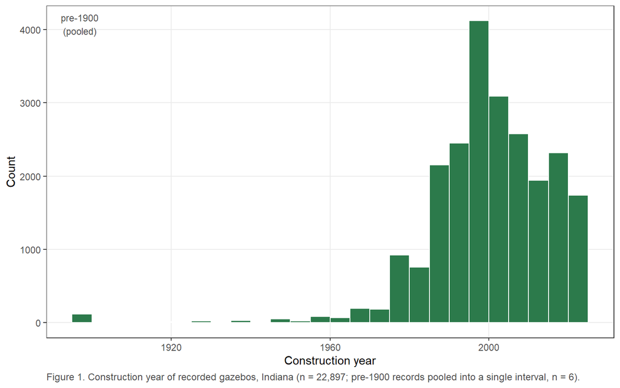

```r
gazebo_year_data <- imp_GA %>%
  st_drop_geometry() %>%
  filter(!is.na(construction_year)) %>%
  mutate(year_binned = if_else(construction_year < 1900, 1897, construction_year))

n_dated       <- nrow(gazebo_year_data)
n_pre1900     <- sum(gazebo_year_data$construction_year < 1900)
n_pre1850     <- sum(gazebo_year_data$construction_year < 1850)
n_exactly1900 <- sum(gazebo_year_data$construction_year == 1900)

fig1_cap <- wrap_cap(paste0(
  "Figure 1. Construction year of recorded gazebos, Indiana (n = ", comma(n_dated),
  "; pre-1900 records pooled into a single interval, n = ", comma(n_pre1900), ")."
))

ggplot(gazebo_year_data, aes(x = year_binned)) +
  geom_histogram(binwidth = 5, boundary = 1900, fill = "#2c7a4b", color = "white") +
  annotate("text", x = 1897, y = Inf, label = "pre-1900\n(pooled)",
           vjust = 1.4, size = 3, color = "grey30") +
  labs(x = "Construction year", y = "Count", caption = fig1_cap) +
  theme_academic()
```

Of the 22,897 records with a usable construction date, 6 predate 1900 and 4 predate 1850. `1900` is a common default value in assessor software for an unknown construction date, and 114 records are dated to that exact year, a disproportionate share for a single year. The apparent nineteenth-century establishment pulse is therefore better read as missing data than as a genuine historical pattern.

### 2.3 Morphology

**See code**

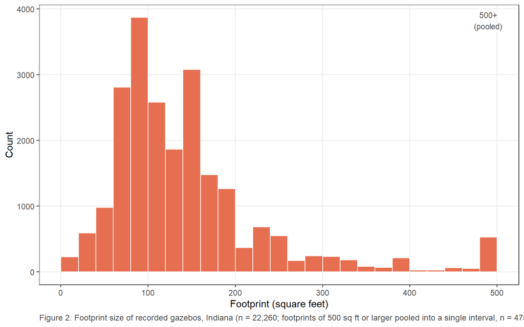

```r
morph_data <- imp_GA %>%
  st_drop_geometry() %>%
  filter(IMPROVEMENT_SIZE > 0)

size_cutoff <- 500
n_size_pooled <- sum(morph_data$IMPROVEMENT_SIZE >= size_cutoff)

fig2_cap <- wrap_cap(paste0(
  "Figure 2. Footprint size of recorded gazebos, Indiana (n = ", comma(nrow(morph_data)),
  "; footprints of ", size_cutoff, " sq ft or larger pooled into a single interval, n = ",
  comma(n_size_pooled), ")."
))

morph_data %>%
  mutate(size_binned = if_else(IMPROVEMENT_SIZE >= size_cutoff, size_cutoff - 10, IMPROVEMENT_SIZE)) %>%
  ggplot(aes(x = size_binned)) +
  geom_histogram(binwidth = 20, boundary = size_cutoff, fill = "#e76f51", color = "white") +
  annotate("text", x = size_cutoff - 10, y = Inf, label = paste0(size_cutoff, "+\n(pooled)"),
           vjust = 1.4, size = 3, color = "grey30") +
  labs(x = "Footprint (square feet)", y = "Count", caption = fig2_cap) +
  theme_academic()
```

**See code**

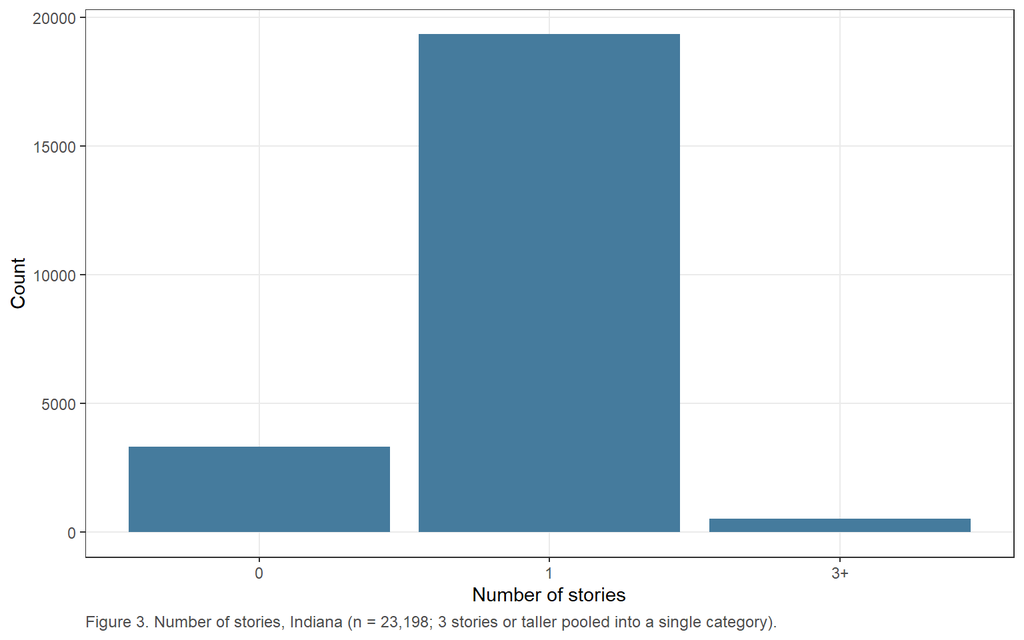

```r
height_cutoff <- 3
height_summary <- imp_GA %>%
  st_drop_geometry() %>%
  filter(!is.na(STORY_HEIGHT_OR_HEIGHT)) %>%
  mutate(
    story_factor = STORY_HEIGHT_OR_HEIGHT / 100,
    story_binned = if_else(story_factor >= height_cutoff, paste0(height_cutoff, "+"), as.character(story_factor))
  ) %>%
  count(story_binned, name = "n_gazebos") %>%
  mutate(story_binned = fct_reorder(story_binned, parse_number(story_binned)))

fig3_cap <- wrap_cap(paste0(
  "Figure 3. Number of stories, Indiana (n = ", comma(sum(height_summary$n_gazebos)),
  "; ", height_cutoff, " stories or taller pooled into a single category)."
))

ggplot(height_summary, aes(x = story_binned, y = n_gazebos)) +
  geom_col(fill = "#457b9d") +
  labs(x = "Number of stories", y = "Count", caption = fig3_cap) +
  theme_academic()
```

**See code**

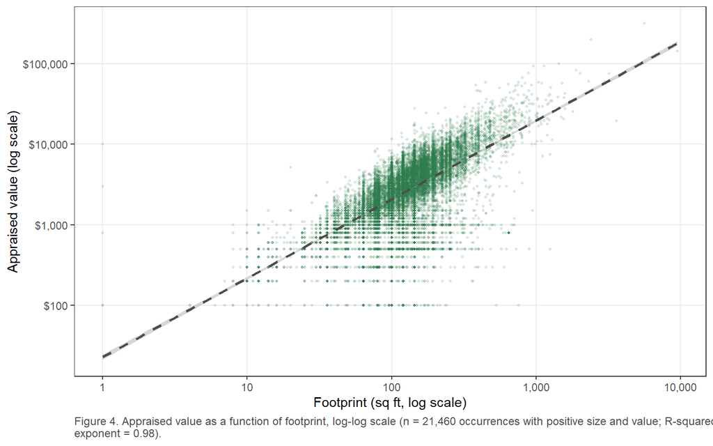

```r
value_data <- morph_data %>% filter(APPRAISED_VALUE > 0)
value_size_model <- lm(log(APPRAISED_VALUE) ~ log(IMPROVEMENT_SIZE), data = value_data)
value_size_summary <- summary(value_size_model)
n_vs    <- nobs(value_size_model)
r2_vs   <- round(value_size_summary$r.squared, 3)
beta_vs <- round(coef(value_size_model)[["log(IMPROVEMENT_SIZE)"]], 2)

fig4_cap <- wrap_cap(paste0(
  "Figure 4. Appraised value as a function of footprint, log-log scale (n = ", comma(n_vs),
  " occurrences with positive size and value; R-squared = ", r2_vs, ", scaling exponent = ", beta_vs, ")."
))

ggplot(value_data, aes(x = IMPROVEMENT_SIZE, y = APPRAISED_VALUE)) +
  geom_point(alpha = 0.15, color = "#2c7a4b", size = 0.8) +
  geom_smooth(method = "lm", se = TRUE, color = "grey30", linetype = "dashed") +
  scale_x_log10(labels = comma) +
  scale_y_log10(labels = dollar) +
  labs(x = "Footprint (sq ft, log scale)", y = "Appraised value (log scale)", caption = fig4_cap) +
  theme_academic()
```

Most individuals fall within a modest footprint range consistent with a conventional garden gazebo (Figure 2); the pooled interval captures the same pavilion-like outliers discussed above. Height is overwhelmingly one story, with a small pooled tail of taller records (Figure 3). Appraised value scales positively with footprint (R² = 0.431, scaling exponent = 0.98), a roughly proportional relationship consistent with straightforward per-square-foot appraisal rather than a premium for larger structures.

### 2.4 Geographic distribution

County-level occurrence counts and, where available, parcel-level coordinates were combined into a single distribution map. Per-capita prevalence (occurrences per 10,000 residents) uses county population from the American Community Survey (below).

**See code**

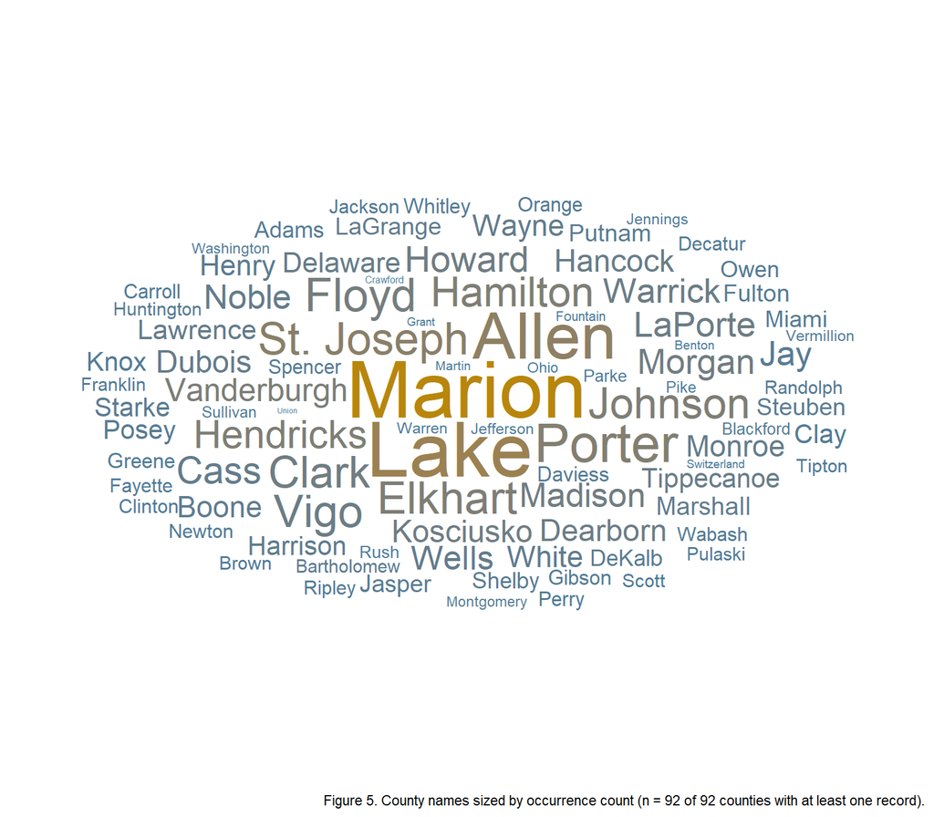

```r
county_leaderboard <- imp_GA %>%
  st_drop_geometry() %>%
  count(COUNTY_NAME, name = "n_gazebos") %>%
  arrange(desc(n_gazebos))

top_county <- county_leaderboard %>% slice_max(n_gazebos, n = 1)

fig5_cap <- wrap_cap(paste0(
  "Figure 5. County names sized by occurrence count (n = ", n_distinct(imp_GA$COUNTY_NAME),
  " of 92 counties with at least one record)."
))

ggplot(county_leaderboard, aes(label = COUNTY_NAME, size = n_gazebos, color = n_gazebos)) +
  ggwordcloud::geom_text_wordcloud(area_corr = TRUE, rm_outside = TRUE) +
  scale_size_area(max_size = 40) +
  scale_color_gradient(low = "#457b9d", high = "#b8860b") +
  labs(caption = fig5_cap) +
  theme_minimal()
```

Marion County leads the state with 1845 recorded occurrences.

**See code**

```r
library(tidycensus)

build_acs_data <- function() {
  get_acs(
    geography  = "county",
    state      = "IN",
    year       = 2024,
    survey     = "acs5",
    variables  = c(
      population    = "B01003_001",
      median_income = "B19013_001",
      median_age    = "B01002_001",
      owner_occ     = "B25003_002",
      total_occ     = "B25003_001",
      housing_units = "B25001_001"
    ),
    geometry   = TRUE,
    keep_geo_vars = TRUE,
    output     = "wide"
  ) %>%
    mutate(
      COUNTY_NAME = NAME.x,
      pct_owner_occ = owner_occE / total_occE * 100,
      avg_acres_per_unit = (ALAND / 4046.8564224) / housing_unitsE
    ) %>%
    st_make_valid()
}

acs_data <- read_or_build(file.path(cache_dir, "acs_data.rds"), build_acs_data)

gazebo_density <- county_leaderboard %>%
  left_join(st_drop_geometry(acs_data), by = "COUNTY_NAME") %>%
  mutate(
    area_km2    = ALAND / 1e6,
    pop_density = populationE / area_km2,
    density_tier = cut(
      pop_density,
      breaks = c(-Inf, 50, 300, Inf),
      labels = c("Rural", "Suburban", "Urban")
    ),
    gazebos_per_10k = round(n_gazebos / populationE * 10000, 2)
  ) %>%
  arrange(desc(gazebos_per_10k))

library(arcgislayers)
parcels_url <- "https://gisdata.in.gov/server/rest/services/Hosted/Parcel_Boundaries_of_Indiana_Current/FeatureServer/0"
id_field <- "state_parcel_id"

build_gazebo_parcels <- function() {
  parcels_layer <- arc_open(parcels_url)
  ids <- unique(imp_GA$PARCEL_NUMBER)
  id_batches <- split(ids, ceiling(seq_along(ids) / 500))

  fetch_batch <- function(batch_ids) {
    where_clause <- paste0(id_field, " IN ('", paste(batch_ids, collapse = "','"), "')")
    arc_select(parcels_layer, where = where_clause)
  }

  id_batches %>%
    map_dfr(fetch_batch) %>%
    rename(PARCEL_NUMBER = all_of(id_field)) %>%
    st_make_valid()
}

gazebo_parcels <- read_or_build(file.path(cache_dir, "gazebo_parcels.rds"), build_gazebo_parcels)

gazebo_points <- gazebo_parcels %>%
  st_centroid() %>%
  left_join(
    imp_GA %>% st_drop_geometry() %>%
      select(PARCEL_NUMBER, COUNTY_NAME, APPRAISED_VALUE, construction_year),
    by = "PARCEL_NUMBER"
  )

top10 <- gazebo_points %>% slice_max(APPRAISED_VALUE, n = 10)

multi_gazebo_points <- gazebo_points %>%
  semi_join(howmany, by = "PARCEL_NUMBER") %>%
  left_join(howmany %>% select(PARCEL_NUMBER, n_gazebos), by = "PARCEL_NUMBER")

county_map <- acs_data %>%
  left_join(
    gazebo_density %>% select(COUNTY_NAME, n_gazebos, gazebos_per_10k, density_tier),
    by = "COUNTY_NAME"
  )

pal <- colorNumeric("magma", domain = county_map$gazebos_per_10k, na.color = "#d9d9d9")
county_pal <- colorFactor(palette = "Spectral", domain = gazebo_points$COUNTY_NAME)

m <- leaflet(elementId = "gazebo-map", height = 650) %>%
  addProviderTiles(providers$CartoDB.Positron, group = "Map") %>%
  addProviderTiles(providers$Esri.WorldImagery, group = "Satellite") %>%
  addPolygons(
    data = county_map,
    fillColor = ~pal(gazebos_per_10k), fillOpacity = 0.75, color = "white", weight = 1,
    label = ~paste0(
      COUNTY_NAME, ": ",
      ifelse(is.na(gazebos_per_10k), "no recorded occurrences", paste(gazebos_per_10k, "per 10k residents"))
    ),
    highlightOptions = highlightOptions(weight = 3, color = "black", bringToFront = TRUE),
    group = "Prevalence (per 10k residents)"
  ) %>%
  addLegend(pal = pal, values = county_map$gazebos_per_10k, title = "Per 10k<br>residents",
            na.label = "N/A", group = "Prevalence (per 10k residents)") %>%
  addCircleMarkers(
    data = gazebo_points,
    radius = 3, stroke = FALSE, fillOpacity = 0.6,
    color = ~county_pal(COUNTY_NAME),
    clusterOptions = markerClusterOptions(),
    popup = ~paste0(
      "<b>", COUNTY_NAME, " County</b><br>Parcel: ", PARCEL_NUMBER,
      "<br>Appraised value: ", dollar(APPRAISED_VALUE), "<br>Built: ", construction_year
    ),
    group = "Individual occurrences"
  ) %>%
  addAwesomeMarkers(
    data = top10,
    icon = awesomeIcons(icon = "star", library = "fa", markerColor = "gold"),
    popup = ~paste0("<b>Top-10 by value</b><br>", COUNTY_NAME, " County<br>", dollar(APPRAISED_VALUE)),
    group = "Top 10 by value"
  ) %>%
  addAwesomeMarkers(
    data = multi_gazebo_points,
    icon = awesomeIcons(icon = "circle", library = "fa", markerColor = "orange"),
    popup = ~paste0(COUNTY_NAME, " County, ", n_gazebos, " occurrences on this parcel"),
    group = "Multiple gazebos"
  )

library(leaflet.extras)
pts <- st_coordinates(gazebo_points)
m <- m %>%
  addHeatmap(
    lng = pts[, 1], lat = pts[, 2],
    blur = 25, max = 0.05, radius = 18,
    group = "Point density"
  ) %>%
  hideGroup("Point density") %>%
  addControl(
    html = paste0(
      '<div style="background:white; padding:6px 10px; border-radius:4px; font-size:12px;">',
      '<b>Prevalence metric</b><br>',
      '<label><input type="radio" name="metricChoice" value="prevalence" checked ',
      'onchange="window.gazeboSetMetric(\'prevalence\')"> Per 10k residents</label><br>',
      '<label><input type="radio" name="metricChoice" value="density" ',
      'onchange="window.gazeboSetMetric(\'density\')"> Point density</label></div>'
    ),
    position = "topright"
  )
m <- htmlwidgets::onRender(m, "
  function(el, x) {
    var map = this;
    window.gazeboSetMetric = function(choice) {
      var prevalence = map.layerManager.getLayerGroup('Prevalence (per 10k residents)');
      var density = map.layerManager.getLayerGroup('Point density');
      if (!prevalence || !density) return;
      if (choice === 'density') {
        map.addLayer(density);
        map.removeLayer(prevalence);
      } else {
        map.addLayer(prevalence);
        map.removeLayer(density);
      }
    };
  }
")

m <- m %>%
  addLayersControl(
    position = "topleft",
    baseGroups = c("Map", "Satellite"),
    overlayGroups = c("Individual occurrences", "Top 10 by value", "Multiple gazebos"),
    options = layersControlOptions(collapsed = FALSE)
  ) %>%
  hideGroup(c("Individual occurrences", "Top 10 by value", "Multiple gazebos"))

map_cap <- wrap_cap(paste0(
  "Figure 6. Prevalence per 10,000 residents by county (n = ",
  sum(!is.na(county_map$gazebos_per_10k)), " counties), with point density, ",
  "individual occurrences, and notable parcels available as alternate layers."
))

htmltools::tagList(
  m,
  htmltools::div(
    map_cap,
    style = "font-size: 0.85em; color: #555; margin-top: 4px; margin-bottom: 1.5em;"
  )
)
```

[interactive chart not shown]

Figure 6. Prevalence per 10,000 residents by county (n = 92 counties), with point density, individual occurrences, and notable parcels available as alternate layers.

Figure 6 shows the resulting distribution: prevalence per 10,000 residents by county is the default view, with a raw point-density surface available as an alternate via the toggle in the top-right corner, and individual occurrences, the ten highest-value individuals, and multi-gazebo parcels available as independent overlay layers.

### 2.5 Habitat associations

County population, income, age structure, and housing tenure were tested individually against gazebo prevalence before being combined into a single model.

**See code**

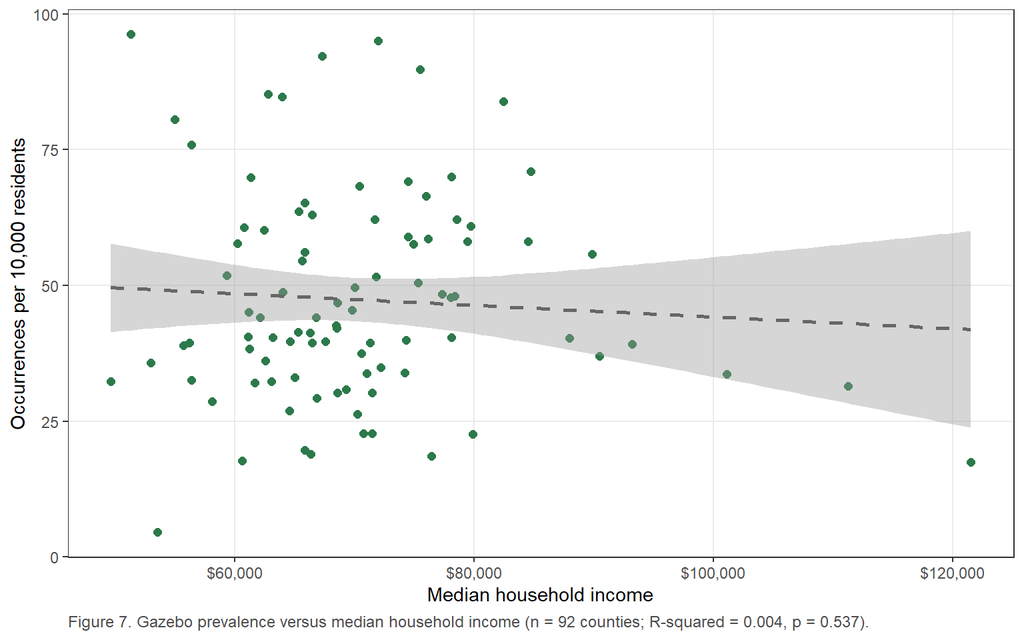

```r
income_model <- lm(gazebos_per_10k ~ median_incomeE, data = gazebo_density)
income_summary <- summary(income_model)
n_income  <- nobs(income_model)
r2_income <- round(income_summary$r.squared, 3)
p_income  <- signif(coef(income_summary)[2, "Pr(>|t|)"], 3)

fig7_cap <- wrap_cap(paste0(
  "Figure 7. Gazebo prevalence versus median household income (n = ", n_income,
  " counties; R-squared = ", r2_income, ", p = ", p_income, ")."
))

ggplot(gazebo_density, aes(x = median_incomeE, y = gazebos_per_10k)) +
  geom_point(color = "#2c7a4b", size = 2) +
  geom_smooth(method = "lm", se = TRUE, color = "grey40", linetype = "dashed") +
  scale_x_continuous(labels = dollar) +
  labs(x = "Median household income", y = "Occurrences per 10,000 residents", caption = fig7_cap) +
  theme_academic()
```

**See code**

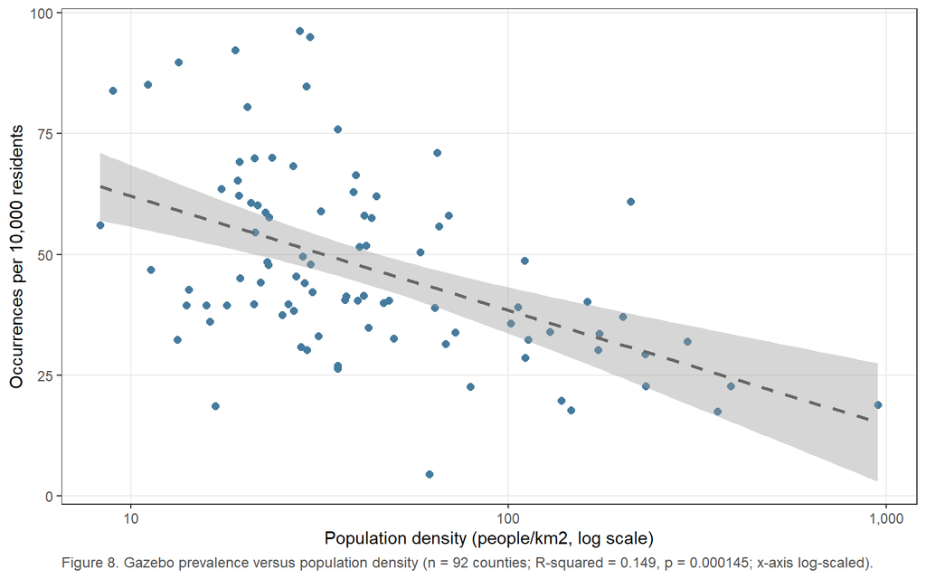

```r
density_model <- lm(gazebos_per_10k ~ pop_density, data = gazebo_density)
density_summary <- summary(density_model)
n_pd  <- nobs(density_model)
r2_pd <- round(density_summary$r.squared, 3)
p_pd  <- signif(coef(density_summary)[2, "Pr(>|t|)"], 3)

fig8_cap <- wrap_cap(paste0(
  "Figure 8. Gazebo prevalence versus population density (n = ", n_pd,
  " counties; R-squared = ", r2_pd, ", p = ", p_pd, "; x-axis log-scaled)."
))

ggplot(gazebo_density, aes(x = pop_density, y = gazebos_per_10k)) +
  geom_point(color = "#457b9d", size = 2) +
  geom_smooth(method = "lm", se = TRUE, color = "grey40", linetype = "dashed") +
  scale_x_log10(labels = comma) +
  labs(x = "Population density (people/km2, log scale)", y = "Occurrences per 10,000 residents", caption = fig8_cap) +
  theme_academic()
```

**See code**

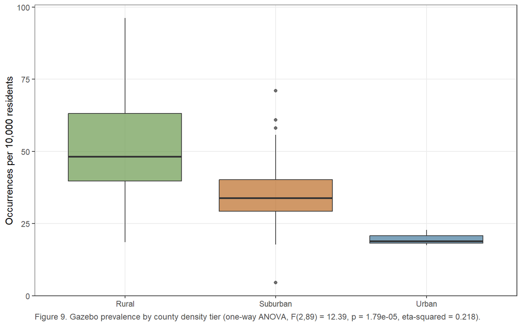

```r
tier_data <- gazebo_density %>% filter(!is.na(density_tier))
tier_aov  <- aov(gazebos_per_10k ~ density_tier, data = tier_data)
aov_table <- summary(tier_aov)[[1]]
ss_tier   <- aov_table["density_tier", "Sum Sq"]
ss_resid  <- aov_table["Residuals", "Sum Sq"]
eta2_tier <- round(ss_tier / (ss_tier + ss_resid), 3)
f_tier    <- round(aov_table["density_tier", "F value"], 2)
df1_tier  <- aov_table["density_tier", "Df"]
df2_tier  <- aov_table["Residuals", "Df"]
p_tier    <- signif(aov_table["density_tier", "Pr(>F)"], 3)

fig9_cap <- wrap_cap(paste0(
  "Figure 9. Gazebo prevalence by county density tier (one-way ANOVA, F(", df1_tier, ",", df2_tier,
  ") = ", f_tier, ", p = ", p_tier, ", eta-squared = ", eta2_tier, ")."
))

ggplot(tier_data, aes(x = density_tier, y = gazebos_per_10k, fill = density_tier)) +
  geom_boxplot(alpha = 0.7, show.legend = FALSE) +
  scale_fill_manual(values = c(Rural = "#6a994e", Suburban = "#bc6c25", Urban = "#457b9d")) +
  labs(x = NULL, y = "Occurrences per 10,000 residents", caption = fig9_cap) +
  theme_academic()
```

**See code**

```r
gazebo_model <- lm(
  gazebos_per_10k ~ populationE + housing_unitsE + median_incomeE +
    median_ageE + pct_owner_occ + pop_density + avg_acres_per_unit,
  data = gazebo_density
)
full_summary <- summary(gazebo_model)
r2_full    <- round(full_summary$r.squared, 3)
adjr2_full <- round(full_summary$adj.r.squared, 3)
n_full     <- nobs(gazebo_model)

coef_table <- as.data.frame(coef(full_summary)) %>%
  rownames_to_column("Term") %>%
  rename(`Std. Error` = `Std. Error`, `t value` = `t value`, `p value` = `Pr(>|t|)`) %>%
  mutate(across(where(is.numeric), ~signif(.x, 3)))

tbl2_cap <- paste0(
  "Table 2. Multiple regression of gazebo prevalence on all county-level ACS covariates ",
  "(population, housing units, median income, median age, owner-occupancy rate, population ",
  "density, and acres per housing unit; R-squared = ", r2_full,
  ", adjusted R-squared = ", adjr2_full, ", n = ", n_full, " counties)."
)

knitr::kable(coef_table, caption = tbl2_cap)
```

Table 2. Multiple regression of gazebo prevalence on all county-level ACS covariates (population, housing units, median income, median age, owner-occupancy rate, population density, and acres per housing unit; R-squared = 0.347, adjusted R-squared = 0.292, n = 92 counties).

| Term | Estimate | Std. Error | t value | p value |
| --- | --- | --- | --- | --- |
| (Intercept) | -4.98e+01 | 2.87e+01 | -1.740 | 0.0859 |
| populationE | -3.60e-04 | 3.14e-04 | -1.140 | 0.2550 |
| housing_unitsE | 6.37e-04 | 7.46e-04 | 0.854 | 0.3950 |
| median_incomeE | -7.21e-05 | 2.16e-04 | -0.333 | 0.7400 |
| median_ageE | 7.29e-01 | 7.43e-01 | 0.982 | 0.3290 |
| pct_owner_occ | 9.13e-01 | 4.63e-01 | 1.970 | 0.0522 |
| pop_density | 6.80e-02 | 6.82e-02 | 0.997 | 0.3220 |
| avg_acres_per_unit | 2.36e-01 | 1.68e-01 | 1.400 | 0.1650 |

Neither income (R² = 0.004, p = 0.537) nor population density alone (R² = 0.149, p = 1.45^{-4}) is a strong univariate predictor of gazebo prevalence, though density performs somewhat better. Treating county density as a categorical rural/suburban/urban factor performs better still: the tier effect is statistically significant (F(2, 89) = 12.39, p = 1.79^{-5}), accounting for 22% of variance in county-level prevalence (η² = 0.218).

The full model incorporates every county-level covariate drawn from the ACS pull, population, housing units, median income, median age, owner-occupancy rate, population density, and acres per housing unit, and explains R² = 0.347 of the variance (adjusted R² = 0.292, n = 92 counties). Several of these terms are mechanically related (population, housing units, density, and acres-per-unit all derive in part from the same land-area figure), so individual coefficients should be read with that collinearity in mind rather than interpreted as independent effects. The model’s modest fit indicates that most county-to-county variation in gazebo prevalence is not explained by the demographic covariates available here.

**Additional covariates for future models:** true parcel-level lot size (aggregated by county rather than proxied by density), housing stock age and structure type, official rural-urban commuting area classification in place of the density-tier proxy used here, median home value and length of tenure, climate and precipitation normals, and water or lake frontage.

### 2.6 Aggregation and ownership

Some parcels carry more than one recorded gazebo. Ownership records for these parcels were retrieved from the local assessor database and classified by keyword as public/institutional, business entity, or individual.

**See code**

```r
build_multi_owners <- function() {
  ids <- unique(howmany$PARCEL_NUMBER)
  id_batches <- split(ids, ceiling(seq_along(ids) / 300))
  fetch_batch <- function(batch_ids) {
    q <- paste0(
      "SELECT PARCEL_NUMBER, OWNER_NAME FROM PARCEL WHERE PARCEL_NUMBER IN ('",
      paste(batch_ids, collapse = "','"), "')"
    )
    st_read(dsn = gdb, query = q, quiet = TRUE)
  }
  id_batches %>% map_dfr(fetch_batch)
}

multi_owners <- read_or_build(file.path(cache_dir, "multi_owners.rds"), build_multi_owners)

public_keywords   <- "\\bPARK\\b|\\bCITY OF\\b|\\bTOWN OF\\b|\\bCOUNTY\\b|\\bSCHOOL\\b|\\bCHURCH\\b|\\bTOWNSHIP\\b|\\bSTATE OF\\b|\\bDEPT\\b|\\bDEPARTMENT\\b|\\bBOARD OF\\b|\\bLIBRARY\\b|\\bFIRE\\b|\\bPOLICE\\b|\\bUNIVERSITY\\b|\\bCOLLEGE\\b"
business_keywords <- "\\bLLC\\b|\\bINC\\b|\\bCORP\\b|\\bTRUST\\b|\\bASSOCIATION\\b|\\bHOA\\b|\\bLP\\b|\\bLTD\\b"

howmany_owners <- howmany %>%
  left_join(st_drop_geometry(multi_owners), by = "PARCEL_NUMBER") %>%
  mutate(
    Owner_Type = case_when(
      str_detect(toupper(OWNER_NAME), public_keywords)   ~ "Public / institutional",
      str_detect(toupper(OWNER_NAME), business_keywords) ~ "Business entity",
      TRUE ~ "Individual"
    )
  )

owner_type_summary <- howmany_owners %>%
  group_by(Owner_Type) %>%
  summarise(n = n(), n_tot = sum(n_gazebos), .groups = "drop")

tbl3_cap <- paste0(
  "Table 3. Ownership type for multi-gazebo parcels (n = ", nrow(howmany_owners),
  " parcels, ", sum(owner_type_summary$n_tot), " occurrences). Classification is keyword-based, not a legal determination."
)

knitr::kable(
  owner_type_summary,
  col.names = c("Owner type", "Parcels", "Total occurrences"),
  caption = tbl3_cap
)
```

Table 3. Ownership type for multi-gazebo parcels (n = 418 parcels, 924 occurrences). Classification is keyword-based, not a legal determination.

| Owner type | Parcels | Total occurrences |
| --- | --- | --- |
| Business entity | 99 | 229 |
| Individual | 275 | 586 |
| Public / institutional | 44 | 109 |

**See code**

```r
priciest <- imp_GA %>% st_drop_geometry() %>% slice_max(APPRAISED_VALUE, n = 1)
```

Of the 418 multi-gazebo parcels, 44 are owned by a public or institutional entity, consistent with a park or municipal-shelter interpretation. The remaining 374 are owned by individuals or business entities, indicating that multi-gazebo aggregation is not primarily a public-land phenomenon.

The single highest-value individual in the dataset is located in Elkhart County, appraised at $316,000, constructed in 2023.

## 3 Discussion and limitations

The gazebo, as recorded in Indiana’s assessment data, is best understood as a heterogeneous category rather than a single structure type. The size distribution alone suggests a mixture of ornamental garden structures and larger, functionally distinct pavilions sharing a single administrative code, and no covariate in this study distinguishes between them post hoc.

County-level demographic covariates explain relatively little variation in gazebo prevalence, even in combination. This may reflect a genuine absence of strong demographic drivers at the county scale, a mismatch between county-level aggregation and household-level decision-making, or the absence of more directly relevant covariates (true lot size, housing age, climate) from the present model. The rural/suburban/urban density tier outperformed any single continuous covariate, suggesting the relationship, to the extent one exists, may not be linear.

The ownership classification for multi-gazebo parcels relies on keyword matching against owner names and will misclassify entities with atypical naming conventions. It should be treated as an approximate partition rather than a verified legal classification.

Extension of this approach to neighboring states would allow a comparative test of whether the patterns observed here are specific to Indiana or general to the region.

## 4 Data sources

- Indiana county assessor, 2025 Real Property geodatabase, `IMPROVE` and `PARCEL` tables
- Indiana Geographic Information Office, Parcel Boundaries of Indiana Current, ArcGIS REST service, distributed via the [Indiana GIS Data Harvest](https://data-harvest-ingov.hub.arcgis.com/)
- U.S. Census Bureau, [American Community Survey](https://www.census.gov/programs-surveys/acs), 2024 five-year estimates